# MSDS688 -- Artifical Intelligence

## Week 6 - Acting in an Uncertain World

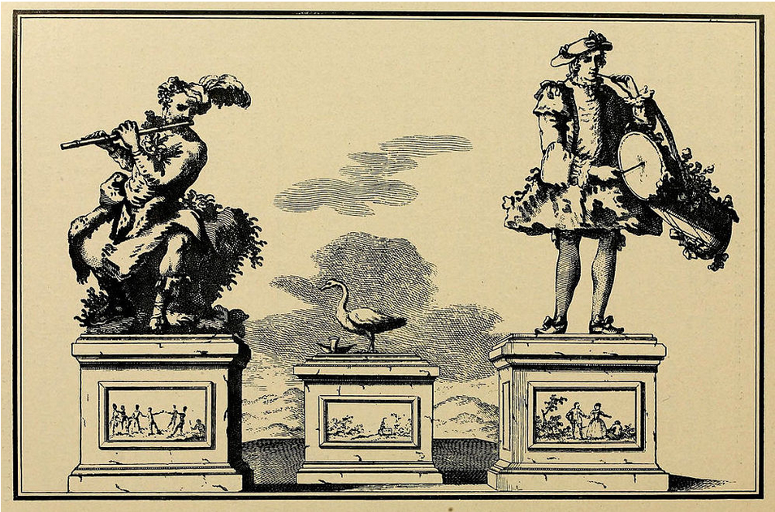

```python
Image('images/vaucansons-automata.png')
```

Vaucanson’s third automaton was the notorious “Defecating Duck”. While it flapped its wings and cavorted duckishly, its main attraction was that it swallowed bits of corn or grain and excreted them at the other end in a changed form. (This part of the act was a fake: the corn that went in the front remained hidden for surreptitious removal, while the rear end was preloaded.)

Cite: Riskin, J. (n.d.). Frolicsome Engines: The Long Prehistory of Artificial Intelligence. Retrieved April 10, 2018, from https://publicdomainreview.org/2016/05/04/frolicsome-engines-the-long-prehistory-of-artificial-intelligence/

## Bayesian Belief Network

- Combination of probability and graph theory
- Nodes are random variables with probability values
- Edges are conditional dependencies and model causality

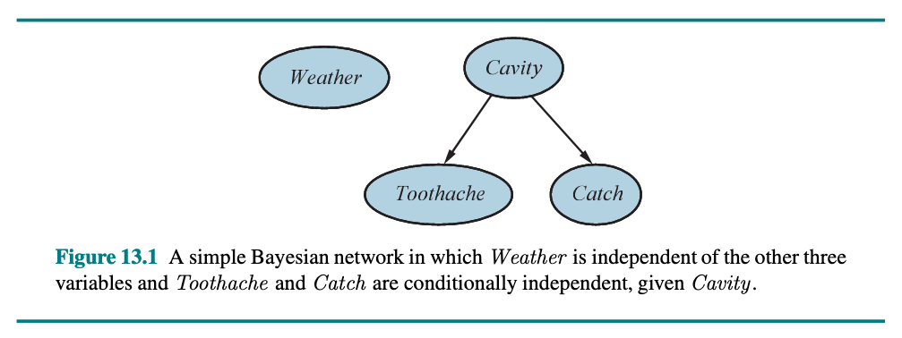

```python
Image('images/bayes-net-toothache-model.png')
```

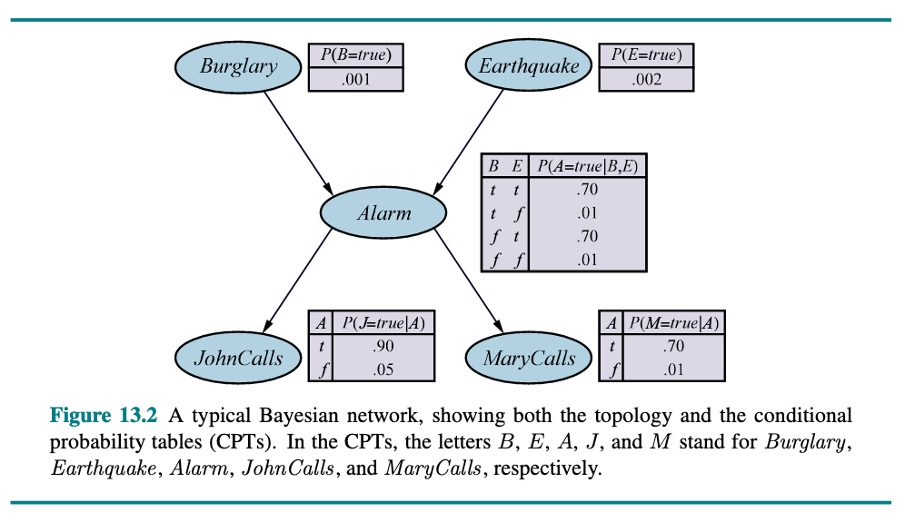

```python
Image('images/Figure-S14-2-bayesian-belief-net.png')
```

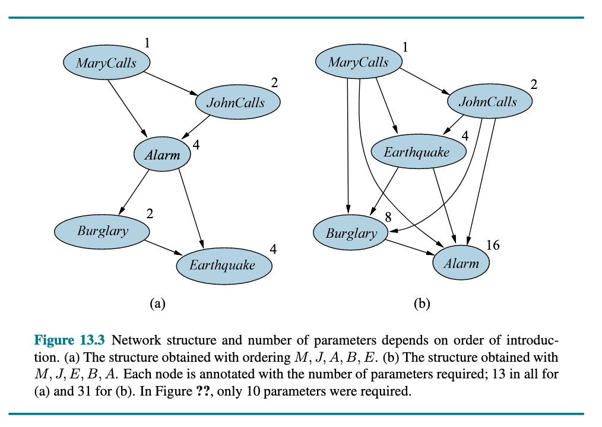

```python
Image('images/bayes-net-competing-models.png')
```

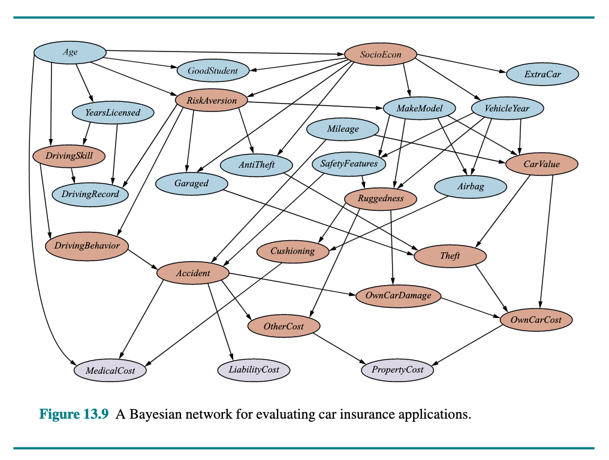

```python
Image('images/bayes-net-car-insurance.png')
```

### Citation

“Artificial Intelligence: A Modern Approach(4th Ed.).” Artificial Intelligence: A Modern Approach, 2020, aima.cs.berkeley.edu/. PDF file under Figures tab. http://aima.cs.berkeley.edu/figures.pdf.